# Niveles de Depresión y Consumo de Alcohol en Europa en estudiantes universitarios.

Margarita Auguzarova - Carlota Mendoza Hurtado

## Enlace al repositorio

[GitHub Niveles_depresion](https://github.com/RitaAguz/Niveles_depresion.git)

## 1. Introducción

La etapa universitaria suele representarse como un periodo de independencia, descubrimiento y nuevas experiencias. Sin embargo, para una parte importante de estudiantes, esta etapa también significa elevados niveles de presión académica e incertidumbre sobre el futuro laboral. Todos estos factores se combinan para generar un entorno que puede afectar de manera significativa a la salud mental de los estudiantes derivando en conductas autodestructivas.

### 1.1 Qué se sabe

En varios artículos científicos recientes se ha observado un incremento en la prevalencia de ansiedad y depresión entre estudiantes universitarios. Estudios recientes que evidencian este crecimiento incluyen trabajos sobre estudiantes de enfermería (Liu et al. 2024), revisiones sistemáticas en China (Huang, Chen, and Zhang 2022), el consumo de alimentos asociado con síntomas depresivos (Silva and Gomez 2023), y la prevalencia de depresión, ansiedad y estrés en estudiantes universitarios (Almeida and Santos 2020).

*Esta situación, cuando no se atiende adecuadamente, puede derivar en comportamientos de riesgo como el consumo excesivo de alcohol u otras conductas autodestructivas.*

### 1.2 Qué no se sabe

A pesar de la abundantes investigaciones sobre la salud mental, persisten preguntas relevantes. En particular, se desconoce hasta qué punto factores específicos —como la estructura educativa de un país— pueden influir en los niveles de depresión o conducta.

*Aclaración 1: Dada la naturaleza de los datos de Eurostat, este estudio adopta una perspectiva ecológica.*

Estos factores podrían actuar como fuentes adicionales de estrés ya que las condiciones socioambientales del país o región (calidad de vida, modelos educativos, presión social, características del campus, entre otros aspectos) podrían desempeñar un papel importante en la experiencia emocional de los estudiantes.

Este vacío de conocimiento motiva la necesidad de un análisis más desagregado y contextualizado.

*Aclaración 2: Debido al nivel ambicioso de esta investigación, se ha acortado a un estudio en paises de Europa.*

## 2. Objetivo General

Evaluar la correlación a nivel país entre la prevalencia media de síntomas depresivos y el consumo crónico de alcohol en la población terciaria europea, explorando su asociación con el volumen total de la población universitaria (matriculados y egresados).

## 3. Objetivos Específicos

1. **¿Cuál es la prevalencia de depresión general entre los estudiantes y egresados universiatios europeos? ¿Y de consumo de alcohol?** Analizar y visualizar la prevalencia de depresión en la población universitaria europea respecto a variables sociodemográficas. (2014-2019 ya que eurostat no recoge años posteriores). Y de consumo de alcohol.
2. **Correlación Conducta-Emocional.** Determinar si existe una correlación estadísticamente significativa a nivel país entre la prevalencia de síntomas depresivos y la prevalencia de consumo crónico de alcohol en esta población.
3. **¿Cómo se relaciona el volumen total de la población universitaria (suma de matriculados y egresados) de un país con sus tasas medias de depresión y consumo de alcohol?** Evaluar la correlación entre el volumen total de la población universitaria (suma de matriculados y egresados) y las prevalencias de depresión y alcohol en cada país.

## 4. Metodología

### 4.1 Cargar paquetes

Aquí se recogen todos los paquetes utilizados para la realización de la práctica.

```r
library(countrycode)
library(eurostat)
library(dplyr)
library(DT)
library(ggplot2)
library(gganimate)
library(jsonlite)
library(leaflet)
library(plotly)
library(readr)
library(rjson)
library(RColorBrewer)
library(stringr)
library(shiny)
library(sf)
library(tidyr)
library(tibble)
```

### 4.2 Obtención de datos

1. Síntomas depresivos actuales según sexo, edad y país de nacimiento.
2. Síntomas depresivos actuales según sexo, edad y nivel educativo.
3. Egresados según nivel educativo, programa de estudios, sexo y área de estudio.
4. Estudiantes matriculados en educación superior según nivel educativo, programa de estudios, sexo y edad.

```r
# Debido a que los datos obtenidos en eurostat estaban anidados, se ha decidido hacer un .R para poder desanidar los datos y crear .json no anidados, evitando así tener que realizar la transformación cada vez que se realiza un knit. Ahorrando tiempo y espacio.
df_depresion_pais <- jsonlite::fromJSON("OUTPUT/JSON_Planos/DepresionPais_flat.json")
df_depresion_edu <- jsonlite::fromJSON("OUTPUT/JSON_Planos/DepresionEducacion_flat.json")
df_egresados <- jsonlite::fromJSON("OUTPUT/JSON_Planos/Egresados_flat.json")
df_matriculados <- jsonlite::fromJSON("OUTPUT/JSON_Planos/Matriculados_flat.json")
df_alcohol <- jsonlite::fromJSON("OUTPUT/JSON_Planos/Alcohol_flat.json")
```

### 4.3 Pequeña visualización de los json

En ‘visulización.R’ se encuentran códigos cortos que enseñan pequeñas previas sobre como se encuentran los bases de datos que hemos cargado. Como no es algo especialmente relevante, no se va a poner en el .Rmd.

### 4.4 Limpieza y preparación de datos.

Aquí se van a realizar la limpieza y estandarización de los datos. De esta forma nos aseguramos de que estén preparados para ser analizados.

Este paso es fundamental, ya que se eliminan las columnas innecesarias, se ordenan filtran los datos adeemás de asegurarse que no haya demasiadas inconsistencias y los cálculos estadísticos no tengan demasiado margen de error.

En este paso se renombran algunas variables para mejor entendimiento o se crean otras, dependiendo de la necesidad.

#### 4.4.1 Limpieza y estandarización de df_depresion_pais y df_depresion_edu

Como las bases de datos realacionadas con la depresión solo difieren en si una está enfocada al pais mientras que la otra en educación, se ha decidido combinar ambos datasets para evitar posibles confusiones.

```r
# 1. Limpieza y estandarización de df_depresion_pais
# Lo nuevo es la culman isced

df_depresion_pais_clean <- df_depresion_pais %>%
  rename(
    country_code = geo, # pais/region
    year = time         # claridad
  ) %>%

  # Añadir la columna de nivel educativo (isced) con valores NA es para unir los datasets.
  mutate(isced = NA_character_) %>%

  # ordenar y seleccionar las columnas a mantener.
  select(
    year, country_code,
    sex, age,
    c_birth, isced,
    value, freq,
    hlth_pb, unit
  )

# 2. Limpieza y estandarización de df_depresion_edu
# Lo nuevo es la columna c_birth

df_depresion_edu_clean <- df_depresion_edu %>%
  rename(
    freq = "Time frequency",
    unit = "Unit of measure",
    isced = "International Standard Classification of Education (ISCED 2011)",
    hlth_pb = "Health problems",
    sex = "Sex",
    age = "Age class",
    country_name = "Geopolitical entity (reporting)",
    year = "Time"
  ) %>%

  # Añadir la columna de país de nacimiento (c_birth) con valores NA, es para unir los datasets
  mutate(c_birth = NA_character_) %>%

  # Convertir el año a numérico (para coincidir con df_depresion_pais y evitar errores)
  mutate(year = as.numeric(year)) %>%

  # Estandarizar el nombre de los países a códigos (geo) para la unión
  mutate(
    country_code = case_when(
      # Casos especiales los creamos para poder agruparlo y luego quitarlos ya que pueden ser inconvenientes para el análisis
      country_name == "European Union - 27 countries (from 2020)" ~ "EU27_2020",
      country_name == "European Union - 28 countries (2013-2020)" ~ "EU28",
      TRUE ~ countrycode(country_name, origin = 'country.name', destination = 'eurostat') # Se usa el paquete countrycode
    )
  ) %>%

  # ordenar y seleccionar las columnas a mantener.
  select(
    year, country_code,
    sex, age,
    c_birth, isced,
    value, freq,
    hlth_pb, unit
  )
# 3. Combinación de los dataframes
# Se utiliza bind_rows() ya que ambos dataframes tienen la misma estructura de columnas.

df_depresion_all <- bind_rows(df_depresion_pais_clean, df_depresion_edu_clean)

# 4. Aquí es donde eliminamos los casos especiales, una vez que ya tenemos el dataframe con absolutamente todos los datos, ya que es más facil eliminarlo si ya está todo asentado en un sitio.
df_depresion_all <- df_depresion_all %>%
  filter(!country_code %in% c("EU27_2020", "EU28"))

# 5. Verificación de la estructura del dataframe combinado

print("Primeras filas del dataframe de Depresión combinado:")
```

```
## [1] "Primeras filas del dataframe de Depresión combinado:"
```

```r
head(df_depresion_all)
```

```
##   year country_code sex   age c_birth isced value freq hlth_pb unit
## 1 2014           BE   T TOTAL     NAT  <NA>    NA    A     DPR   PC
## 2 2019           BE   T TOTAL     NAT  <NA>   8.3    A     DPR   PC
## 3 2014           BG   T TOTAL     NAT  <NA>   7.9    A     DPR   PC
## 4 2019           BG   T TOTAL     NAT  <NA>   4.5    A     DPR   PC
## 5 2014           CZ   T TOTAL     NAT  <NA>   3.2    A     DPR   PC
## 6 2019           CZ   T TOTAL     NAT  <NA>   4.2    A     DPR   PC
```

```r
print(paste("Número total de filas en el dataframe combinado:", nrow(df_depresion_all)))
```

```
## [1] "Número total de filas en el dataframe combinado: 384"
```

```r
str(df_depresion_all)
```

```
## 'data.frame':    384 obs. of  10 variables:
##  $ year        : num  2014 2019 2014 2019 2014 ...
##  $ country_code: chr  "BE" "BE" "BG" "BG" ...
##  $ sex         : chr  "T" "T" "T" "T" ...
##  $ age         : chr  "TOTAL" "TOTAL" "TOTAL" "TOTAL" ...
##  $ c_birth     : chr  "NAT" "NAT" "NAT" "NAT" ...
##  $ isced       : chr  NA NA NA NA ...
##  $ value       : num  NA 8.3 7.9 4.5 3.2 4.2 6.1 7.9 8.2 8.8 ...
##  $ freq        : chr  "A" "A" "A" "A" ...
##  $ hlth_pb     : chr  "DPR" "DPR" "DPR" "DPR" ...
##  $ unit        : chr  "PC" "PC" "PC" "PC" ...
```

#### 4.4.2 Limpieza y estandarización de df_egresados y df_matriculados

```r
# 1. Limpieza y estandarización de df_egresados (Egresados)
df_egresados_clean <- df_egresados %>%
  rename(
    isced_field = "ISCED Fields of education and training (ISCED-F 2013)",
    isced_level = "International Standard Classification of Education (ISCED 2011)",
    sex = "Sex",
    country_name = "Geopolitical entity (reporting)",
    year = "Time",
    value = "value"
  ) %>%

  # Convertir el año a numérico para evitar conflictos futuros
  mutate(year = as.numeric(year)) %>%

  # Estandarizar el nombre de los países a códigos (geo) para la unión
  mutate(
    country_code = case_when(
      country_name == "European Union - 27 countries (from 2020)" ~ "EU27_2020",
      country_name == "European Union - 28 countries (2013-2020)" ~ "EU28",
      TRUE ~ countrycode(country_name, origin = 'country.name', destination = 'eurostat')
    )
  ) %>%

  # Crear una columna de rama académica simplificada (Clave para los objetivos)
  mutate(
    rama_academica = case_when(
      str_detect(isced_field, "Health and welfare|Veterinary") ~ "Ciencias de la Salud",
      str_detect(isced_field, "Engineering|Manufacturing|Construction") ~ "Ingeniería",
      str_detect(isced_field, "Arts and humanities") ~ "Artes y Humanidades",
      str_detect(isced_field, "Social sciences|Journalism|Information|Business|Administration|Law") ~ "Ciencias Sociales, Empresariales y Derecho",
      str_detect(isced_field, "Natural sciences|Mathematics|Statistics|ICTs") ~ "Ciencias Naturales y TIC",
      str_detect(isced_field, "Education") ~ "Educación",
      str_detect(isced_field, "Services") ~ "Servicios",
      str_detect(isced_field, "Agriculture|Forestry|Fisheries") ~ "Agricultura",
      isced_field == "Total" ~ "Total",
      TRUE ~ "Otras" # Para cualquier otra categoría que no se haya mapeado
    )
  ) %>%

  # ordenar y seleccionar las columnas a mantener.
  select(
    year, country_code,
    sex, isced_level,
    isced_field, rama_academica,
    value) %>%

  # Añadimos una columna para identificar el tipo de población
  mutate(poblacion = "Egresados")
# 2. Limpieza y estandarización de df_matriculados (Matriculados)
# No tenemos la edad pero no pasa nada

df_matriculados_clean <- df_matriculados %>%
 rename(
  isced_field = "ISCED Fields of education and training (ISCED-F 2013)",
  isced_level = "International Standard Classification of Education (ISCED 2011)",
  sex = "Sex",
  country_name = "Geopolitical entity (reporting)",
  year = "Time",
  value = "value"
 ) %>%

  # Convertir el año a numérico para evitar futuros problemas
  mutate(year = as.numeric(year)) %>%
  # Estandarizar el nombre de los países a códigos (geo) para la unión
  mutate(
    country_code = case_when(
      country_name == "European Union - 27 countries (from 2020)" ~ "EU27_2020",
      country_name == "European Union - 28 countries (2013-2020)" ~ "EU28",
      TRUE ~ countrycode(country_name, origin = 'country.name', destination = 'eurostat')
    )
  ) %>%

  mutate(
  rama_academica = case_when(
   str_detect(isced_field, "Health and welfare|Veterinary") ~ "Ciencias de la Salud",
   str_detect(isced_field, "Engineering|Manufacturing|Construction") ~ "Ingeniería",
   str_detect(isced_field, "Arts and humanities") ~ "Artes y Humanidades",
   str_detect(isced_field, "Social sciences|Journalism|Information|Business|Administration|Law") ~ "Ciencias Sociales, Empresariales y Derecho",
   str_detect(isced_field, "Natural sciences|Mathematics|Statistics|ICTs") ~ "Ciencias Naturales y TIC",
   str_detect(isced_field, "Education") ~ "Educación",
   str_detect(isced_field, "Services") ~ "Servicios",
   str_detect(isced_field, "Agriculture|Forestry|Fisheries") ~ "Agricultura",
   isced_field == "Total" ~ "Total",
   TRUE ~ "Otras" # Para cualquier otra categoría que no se haya mapeado
  )
 ) %>%

  # ordenar y seleccionar las columnas a mantener.
  select(year, country_code,
         sex, isced_level,
         isced_field, rama_academica,
         value) %>%
  # Añadimos una columna para identificar el tipo de población
  mutate(poblacion = "Matriculados")
# 3. Aquí quitamos los carácteres especiales de antes
df_egresados_clean <- df_egresados_clean %>%
  filter(!country_code %in% c("EU27_2020", "EU28"))
df_matriculados_clean <- df_matriculados_clean %>%
  filter(!country_code %in% c("EU27_2020", "EU28"))

# 4. Mostrar estructura y primeras filas
print("Estructura de df_egresados_clean:")
```

```
## [1] "Estructura de df_egresados_clean:"
```

```r
str(df_egresados_clean)
```

```
## 'data.frame':    2280 obs. of  8 variables:
##  $ year          : num  2012 2013 2014 2015 2016 ...
##  $ country_code  : chr  "BE" "BE" "BE" "BE" ...
##  $ sex           : chr  "Total" "Total" "Total" "Total" ...
##  $ isced_level   : chr  "Tertiary education (levels 5-8)" "Tertiary education (levels 5-8)" "Tertiary education (levels 5-8)" "Tertiary education (levels 5-8)" ...
##  $ isced_field   : chr  "Total" "Total" "Total" "Total" ...
##  $ rama_academica: chr  "Total" "Total" "Total" "Total" ...
##  $ value         : int  NA 107884 110888 112406 119141 115870 116671 114468 126446 124601 ...
##  $ poblacion     : chr  "Egresados" "Egresados" "Egresados" "Egresados" ...
```

```r
print("Primeras filas de df_egresados_clean (Egresados):")
```

```
## [1] "Primeras filas de df_egresados_clean (Egresados):"
```

```r
head(df_egresados_clean)
```

```
##   year country_code   sex                     isced_level isced_field
## 1 2012           BE Total Tertiary education (levels 5-8)       Total
## 2 2013           BE Total Tertiary education (levels 5-8)       Total
## 3 2014           BE Total Tertiary education (levels 5-8)       Total
## 4 2015           BE Total Tertiary education (levels 5-8)       Total
## 5 2016           BE Total Tertiary education (levels 5-8)       Total
## 6 2017           BE Total Tertiary education (levels 5-8)       Total
##   rama_academica  value poblacion
## 1          Total     NA Egresados
## 2          Total 107884 Egresados
## 3          Total 110888 Egresados
## 4          Total 112406 Egresados
## 5          Total 119141 Egresados
## 6          Total 115870 Egresados
```

```r
print("Estructura de df_matriculados_clean:")
```

```
## [1] "Estructura de df_matriculados_clean:"
```

```r
str(df_matriculados_clean)
```

```
## 'data.frame':    390 obs. of  8 variables:
##  $ year          : num  2014 2015 2016 2017 2018 ...
##  $ country_code  : chr  "BE" "BE" "BE" "BE" ...
##  $ sex           : chr  "Total" "Total" "Total" "Total" ...
##  $ isced_level   : chr  "Tertiary education (levels 5-8)" "Tertiary education (levels 5-8)" "Tertiary education (levels 5-8)" "Tertiary education (levels 5-8)" ...
##  $ isced_field   : chr  "Total" "Total" "Total" "Total" ...
##  $ rama_academica: chr  "Total" "Total" "Total" "Total" ...
##  $ value         : int  495910 504745 508270 526760 515530 519212 521201 539777 549399 550999 ...
##  $ poblacion     : chr  "Matriculados" "Matriculados" "Matriculados" "Matriculados" ...
```

```r
print("Primeras filas de df_matriculados_clean (Matriculados):")
```

```
## [1] "Primeras filas de df_matriculados_clean (Matriculados):"
```

```r
head(df_matriculados_clean)
```

```
##   year country_code   sex                     isced_level isced_field
## 1 2014           BE Total Tertiary education (levels 5-8)       Total
## 2 2015           BE Total Tertiary education (levels 5-8)       Total
## 3 2016           BE Total Tertiary education (levels 5-8)       Total
## 4 2017           BE Total Tertiary education (levels 5-8)       Total
## 5 2018           BE Total Tertiary education (levels 5-8)       Total
## 6 2019           BE Total Tertiary education (levels 5-8)       Total
##   rama_academica  value    poblacion
## 1          Total 495910 Matriculados
## 2          Total 504745 Matriculados
## 3          Total 508270 Matriculados
## 4          Total 526760 Matriculados
## 5          Total 515530 Matriculados
## 6          Total 519212 Matriculados
```

#### 4.4.3 Limpieza y estandarización de df_alcohol_clean

Se limpian los datos de consumo de alcohol además de unir la depresión y el alcohol en un dataset para la futura correlación en el objetivo 2.

```r
df_alcohol_clean <- df_alcohol %>%
  rename(
    year = time,
    country_code = geo,
    c_birth = citizen   # equivalente a "country of birth"
  ) %>%
  mutate(
    isced = NA_character_,   # porque alcohol no tiene nivel educativo
    hlth_pb = "Alcohol consumption"   # Para poder unir con depresión
  ) %>%
  select(
    year, country_code,
    sex, age,
    c_birth, isced,
    value, hlth_pb, unit
  )


# 4. Combinación de los dataframes de salud (Depresión + Alcohol)
df_salud_all <- bind_rows(df_depresion_all, df_alcohol_clean)

# 5. Eliminamos casos especiales y verificamos la estructura
df_salud_all <- df_salud_all %>%
  filter(!country_code %in% c("EU27_2020", "EU28"))

print("Primeras filas del dataframe de SALUD combinado (Depresión + Alcohol):")
```

```
## [1] "Primeras filas del dataframe de SALUD combinado (Depresión + Alcohol):"
```

```r
head(df_salud_all)
```

```
##   year country_code sex   age c_birth isced value freq hlth_pb unit
## 1 2014           BE   T TOTAL     NAT  <NA>    NA    A     DPR   PC
## 2 2019           BE   T TOTAL     NAT  <NA>   8.3    A     DPR   PC
## 3 2014           BG   T TOTAL     NAT  <NA>   7.9    A     DPR   PC
## 4 2019           BG   T TOTAL     NAT  <NA>   4.5    A     DPR   PC
## 5 2014           CZ   T TOTAL     NAT  <NA>   3.2    A     DPR   PC
## 6 2019           CZ   T TOTAL     NAT  <NA>   4.2    A     DPR   PC
```

```r
print(paste("Número total de filas en el dataframe combinado:", nrow(df_salud_all)))
```

```
## [1] "Número total de filas en el dataframe combinado: 694"
```

```r
str(df_salud_all)
```

```
## 'data.frame':    694 obs. of  10 variables:
##  $ year        : num  2014 2019 2014 2019 2014 ...
##  $ country_code: chr  "BE" "BE" "BG" "BG" ...
##  $ sex         : chr  "T" "T" "T" "T" ...
##  $ age         : chr  "TOTAL" "TOTAL" "TOTAL" "TOTAL" ...
##  $ c_birth     : chr  "NAT" "NAT" "NAT" "NAT" ...
##  $ isced       : chr  NA NA NA NA ...
##  $ value       : num  NA 8.3 7.9 4.5 3.2 4.2 6.1 7.9 8.2 8.8 ...
##  $ freq        : chr  "A" "A" "A" "A" ...
##  $ hlth_pb     : chr  "DPR" "DPR" "DPR" "DPR" ...
##  $ unit        : chr  "PC" "PC" "PC" "PC" ...
```

## 5. Preparación de Variables Clave para los objetivos.

### 5.1 Prevalencia de depresión y consumo de alcohol de los matriculados y egresados en Europa.

Con esto tendremos una idea clara de en qué pais a nivel general se posee más niveles de prevalencia de la depresión de la comunidad universitaria y consumo de alcohol. Primero se hizo un gráfico de barras, donde se aprecia la información de forma resumida, mientras que además se añadieron los extras de un mapa interactivo de Europa (debido a que el mapa es geopolítico, hay territorios que técnicamente pertenecen a ese país de Europa, pero los vamos a ignorar)

#### Depresión

```r
df_objetivo1 <- df_depresion_all %>%
  filter(
    hlth_pb %in% c("DPR", "Depressive symptoms"),
    unit %in% c("PC", "Percentage")
  ) %>%
  group_by(country_code) %>%
  summarise(prevalencia_media = mean(value, na.rm = TRUE)) %>%
  mutate(country_name = countrycode(country_code,
                                    origin = "eurostat",
                                    destination = "country.name")) %>%
  arrange(desc(prevalencia_media))
```

```r
# Creación de plot interactivo
ggplotly(
  ggplot(df_objetivo1, aes(x = reorder(country_name, prevalencia_media),
                         y = prevalencia_media)) +
    geom_col(fill = "#49C0BC") +
    coord_flip() +
    labs(
      title = "Prevalencia media de síntomas depresivos por país",
      x = "País",
      y = "Prevalencia Media (%)"
    ) +
    theme_minimal() +
    theme(axis.text.y = element_text(size = 8))
)
```

[interactive chart not shown]

```r
eu_shp <- get_eurostat_geospatial(
  output_class = "sf",
  resolution = "60",
  nuts_level = "0"
) %>%
  select(geo, geometry)
```

```
## Extracting data from eurostat::eurostat_geodata_60_2016
```

```r
map_data <- eu_shp %>%
  left_join(df_objetivo1, by = c("geo" = "country_code"))

pal <- colorNumeric(
  palette = "GnBu",
  domain = map_data$prevalencia_media,
  na.color = "#DCAC80"
)

leaflet(map_data) %>%
  addTiles() %>%
  addPolygons(
    fillColor = ~pal(prevalencia_media),
    weight = 1,
    color = "#595380",
    fillOpacity = 0.8,
    smoothFactor = 0.5,
    highlightOptions = highlightOptions(
      weight = 2,
      color = "black",
      bringToFront = TRUE
    ),
    label = ~paste0(
      "<strong>", country_name, "</strong>",
      "<br>Prevalencia media: ",
      round(prevalencia_media, 2), "%"
    ) %>% lapply(htmltools::HTML)
  ) %>%
  addLegend(
    pal = pal,
    values = ~prevalencia_media,
    title = "Prevalencia Depresión (%)",
    opacity = 1
  )
```

[interactive chart not shown]

#### Consumo de alcohol

```r
df_objetivo1_alcohol <- df_alcohol_clean %>%
  filter(
    hlth_pb == "Alcohol consumption",
    unit == "PC"
  ) %>%
  group_by(country_code) %>%
  summarise(prevalencia_media_alcohol = mean(value, na.rm = TRUE)) %>%
  mutate(country_name = countrycode(country_code,
                                    origin = "eurostat",
                                    destination = "country.name")) %>%
  arrange(desc(prevalencia_media_alcohol))
```

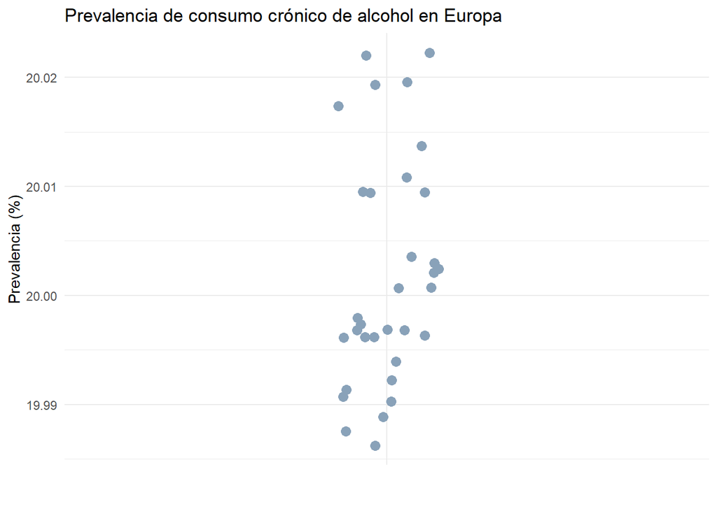

```r
ggplot(df_objetivo1_alcohol, aes(x = "", y = prevalencia_media_alcohol)) +
  geom_jitter(width = 0.1, color = "#89A2B9", size = 3) +
  labs(title = "Prevalencia de consumo crónico de alcohol en Europa",
       y = "Prevalencia (%)", x = "") +
  theme_minimal()
```

```r
eu_shp <- get_eurostat_geospatial(
  output_class = "sf",
  resolution = "60",
  nuts_level = "0"
) %>%
  select(geo, geometry)
```

```
## Extracting data from eurostat::eurostat_geodata_60_2016
```

```r
# Unir con los datos de alcohol
map_data <- eu_shp %>%
  left_join(df_objetivo1_alcohol, by = c("geo" = "country_code"))

pal <- colorNumeric(
  palette = "RdPu",
  domain = map_data$prevalencia_media_alcohol,
  na.color = "#83D2C5"
)

# Crear mapa
leaflet(map_data) %>%
  addTiles() %>%
  addPolygons(
    fillColor = ~pal(prevalencia_media_alcohol),
    weight = 1,
    color = "#595380",
    fillOpacity = 0.8,
    smoothFactor = 0.5,
    highlightOptions = highlightOptions(
      weight = 2,
      color = "black",
      bringToFront = TRUE
    ),
    label = ~paste0(
      "<strong>", country_name, "</strong>",
      "<br>Prevalencia media: ",
      round(prevalencia_media_alcohol, 2), "%"
    ) %>% lapply(htmltools::HTML)
  ) %>%
  addLegend(
    pal = pal,
    values = ~prevalencia_media_alcohol,
    title = "Prevalencia Alcohol (%)",
    opacity = 1
  )
```

[interactive chart not shown]

### 5.2 Correlación Conducta-Emocional

Buscamos determinar si existe una correlación estadísticamente significativa a nivel de país entre la prevalencia de síntomas depresivos y la prevalencia de consumo crónico de alcohol en la población universitaria europea. Para esto, se utilizarán las prevalencias medias por país calculadas en el apartado anterior.

Se unen los dos data frames de prevalencia media por país (df_objetivo1 para depresión y df_objetivo1_alcohol para consumo de alcohol) para crear un único data frame que permita realizar el análisis de correlación.

```r
# 1. Unir los dataframes de prevalencia media
df_correlacion_depresion_alcohol <- df_objetivo1 %>%
 left_join(df_objetivo1_alcohol, by = "country_code") %>%
 # Se elimina la columna redundante de nombre del país de la tabla de alcohol
 select(-country_name.y) %>%
 rename(country_name = country_name.x)

# 2. Filtrar los países que tienen datos para ambas variables
df_correlacion_depresion_alcohol <- df_correlacion_depresion_alcohol %>%
 filter(!is.na(prevalencia_media) & !is.na(prevalencia_media_alcohol))

# 3. Mostrar la estructura y las primeras filas
print("Primeras filas del dataframe de Correlación:")
```

```
## [1] "Primeras filas del dataframe de Correlación:"
```

```r
head(df_correlacion_depresion_alcohol)
```

```
## # A tibble: 6 × 4
##   country_code prevalencia_media country_name prevalencia_media_alcohol
##   <chr>                    <dbl> <chr>                            <dbl>
## 1 SE                        9.45 Sweden                            20.0
## 2 PT                        9.43 Portugal                          20.0
## 3 BE                        8.65 Belgium                           20.0
## 4 DE                        8.65 Germany                           20.0
## 5 FR                        8.62 France                            20
## 6 LU                        8.3  Luxembourg                        20
```

```r
print(paste("Número total de países con datos completos:", nrow(df_correlacion_depresion_alcohol)))
```

```
## [1] "Número total de países con datos completos: 31"
```

```r
# Cálculo de la correlación de Pearson
cor_test_result <- cor.test(
 df_correlacion_depresion_alcohol$prevalencia_media,
 df_correlacion_depresion_alcohol$prevalencia_media_alcohol,
 method = "pearson"
)

# Imprimir el resultado de la prueba
print("Resultado de la prueba de correlación de Pearson:")
```

```
## [1] "Resultado de la prueba de correlación de Pearson:"
```

```r
print(cor_test_result)
```

```
##
##  Pearson's product-moment correlation
##
## data:  df_correlacion_depresion_alcohol$prevalencia_media and df_correlacion_depresion_alcohol$prevalencia_media_alcohol
## t = -3.0472, df = 29, p-value = 0.004886
## alternative hypothesis: true correlation is not equal to 0
## 95 percent confidence interval:
##  -0.7209987 -0.1673364
## sample estimates:
##        cor
## -0.4924757
```

```r
# Extraer los valores clave
cor_coef <- round(cor_test_result$estimate, 3)
p_value <- format.pval(cor_test_result$p.value, digits = 3, eps = 0.001)


# Creación del gráfico de dispersión interactivo con línea de tendencia
plot_correlacion <- ggplot(
 df_correlacion_depresion_alcohol,
 aes(
  x = prevalencia_media,
  y = prevalencia_media_alcohol,
  text = paste(
   "País:", country_name,
   "<br>Depresión:", round(prevalencia_media, 2), "%",
   "<br>Alcohol:", round(prevalencia_media_alcohol, 2), "%"
  )
 )
) +
 geom_point(aes(color = prevalencia_media), size = 3) +
 geom_smooth(method = "lm", se = FALSE, color = "#595380") + # Línea de tendencia (Regresión Lineal)
 scale_color_gradient(low = "#83D2C5", high = "#595380") +
 labs(
  title = paste0("Correlación Depresión vs. Consumo de Alcohol (r = ", cor_coef, ")"),
  x = "Prevalencia Media de Síntomas Depresivos (%)",
  y = "Prevalencia Media de Consumo Crónico de Alcohol (%)",
  color = "Depresión (%)"
 ) +
 theme_minimal() +
 theme(legend.position = "none")

ggplotly(plot_correlacion, tooltip = "text")
```

[interactive chart not shown]

### 5.3 Relación con el Volumen de la Población Universitaria

El objetivo 3 busca evaluar la correlación entre el volumen total de la población universitaria (suma de matriculados y egresados) de un país y sus tasas medias de depresión y consumo de alcohol.

5.3.1 Cálculo del Volumen Total Universitario por País Primero, se calcula el volumen total de estudiantes (matriculados y egresados) por país, sumando los valores de df_egresados_clean y df_matriculados_clean.

```r
# Combinar matriculados y egresados
df_poblacion_uni_total <- bind_rows(df_egresados_clean, df_matriculados_clean) %>%
    # Filtrar solo la categoría 'Total' para evitar dobles conteos y obtener el volumen completo
    filter(isced_field == "Total") %>%
    # Agrupar por país y sumar los valores (el volumen)
    group_by(country_code) %>%
    summarise(
        volumen_uni_total = sum(value, na.rm = TRUE),
        .groups = 'drop'
    ) %>%
    # Añadir el nombre del país
    mutate(country_name = countrycode(country_code,
                                      origin = "eurostat",
                                      destination = "country.name"))

print("Primeras filas del Volumen Total Universitario:")
```

```
## [1] "Primeras filas del Volumen Total Universitario:"
```

```r
head(df_poblacion_uni_total)
```

```
## # A tibble: 6 × 3
##   country_code volumen_uni_total country_name
##   <chr>                    <int> <chr>
## 1 AL                      434409 Albania
## 2 AT                     5832825 Austria
## 3 BA                      606765 Bosnia & Herzegovina
## 4 BE                     7328553 Belgium
## 5 BG                     3464632 Bulgaria
## 6 CH                     4723345 Switzerland
```

5.3.2 Correlación con la Prevalencia de Depresión Se correlaciona el Volumen Total Universitario con la Prevalencia Media de Síntomas Depresivos (df_objetivo1).

```r
# 1. Unir el volumen total con la prevalencia de depresión
df_correlacion_volumen_depresion <- df_objetivo1 %>%
    left_join(df_poblacion_uni_total, by = "country_code") %>%
    select(-country_name.y) %>%
    rename(country_name = country_name.x) %>%
    filter(!is.na(prevalencia_media) & !is.na(volumen_uni_total))

# 2. Cálculo de la correlación de Pearson
cor_test_depresion_volumen <- cor.test(
    df_correlacion_volumen_depresion$prevalencia_media,
    df_correlacion_volumen_depresion$volumen_uni_total,
    method = "pearson"
)

# Extraer los valores clave
cor_coef_dep_vol <- round(cor_test_depresion_volumen$estimate, 3)
p_value_dep_vol <- format.pval(cor_test_depresion_volumen$p.value, digits = 3, eps = 0.001)

print("Resultado de la prueba de correlación (Depresión vs. Volumen Universitario):")
```

```
## [1] "Resultado de la prueba de correlación (Depresión vs. Volumen Universitario):"
```

```r
print(cor_test_depresion_volumen)
```

```
##
##  Pearson's product-moment correlation
##
## data:  df_correlacion_volumen_depresion$prevalencia_media and df_correlacion_volumen_depresion$volumen_uni_total
## t = 0.98055, df = 30, p-value = 0.3347
## alternative hypothesis: true correlation is not equal to 0
## 95 percent confidence interval:
##  -0.1837649  0.4945276
## sample estimates:
##       cor
## 0.1762209
```

```r
# 3. Creación del gráfico de dispersión interactivo
plot_correlacion_dep_vol <- ggplot(
    df_correlacion_volumen_depresion,
    aes(
        x = volumen_uni_total,
        y = prevalencia_media,
        text = paste(
            "País:", country_name,
            "<br>Volumen Uni:", format(volumen_uni_total, big.mark = ","),
            "<br>Depresión:", round(prevalencia_media, 2), "%"
        )
    )
) +
    geom_point(aes(color = prevalencia_media), size = 3) +
    geom_smooth(method = "lm", se = FALSE, color = "#595380") +
    scale_color_gradient(low = "#83D2C5", high = "#595380") +
    labs(
        title = paste0("Correlación Depresión vs. Volumen Universitario (r = ", cor_coef_dep_vol, ")"),
        x = "Volumen Total de Población Universitaria (Matriculados + Egresados)",
        y = "Prevalencia Media de Síntomas Depresivos (%)",
        color = "Depresión (%)"
    ) +
    scale_x_continuous(labels = scales::comma) +
    theme_minimal() +
    theme(legend.position = "none")

ggplotly(plot_correlacion_dep_vol, tooltip = "text")
```

[interactive chart not shown]

5.3.3 Correlación con la Prevalencia de Consumo de Alcohol Se correlaciona el Volumen Total Universitario con la Prevalencia Media de Consumo Crónico de Alcohol (df_objetivo1_alcohol).

```r
# 1. Unir el volumen total con la prevalencia de alcohol
df_correlacion_volumen_alcohol <- df_objetivo1_alcohol %>%
    left_join(df_poblacion_uni_total, by = "country_code") %>%
    select(-country_name.y) %>%
    rename(country_name = country_name.x) %>%
    filter(!is.na(prevalencia_media_alcohol) & !is.na(volumen_uni_total))

# 2. Cálculo de la correlación de Pearson
cor_test_alcohol_volumen <- cor.test(
    df_correlacion_volumen_alcohol$prevalencia_media_alcohol,
    df_correlacion_volumen_alcohol$volumen_uni_total,
    method = "pearson"
)

# Extraer los valores clave
cor_coef_alc_vol <- round(cor_test_alcohol_volumen$estimate, 3)
p_value_alc_vol <- format.pval(cor_test_alcohol_volumen$p.value, digits = 3, eps = 0.001)

print("Resultado de la prueba de correlación (Alcohol vs. Volumen Universitario):")
```

```
## [1] "Resultado de la prueba de correlación (Alcohol vs. Volumen Universitario):"
```

```r
print(cor_test_alcohol_volumen)
```

```
##
##  Pearson's product-moment correlation
##
## data:  df_correlacion_volumen_alcohol$prevalencia_media_alcohol and df_correlacion_volumen_alcohol$volumen_uni_total
## t = 1.1934, df = 29, p-value = 0.2424
## alternative hypothesis: true correlation is not equal to 0
## 95 percent confidence interval:
##  -0.1494432  0.5300580
## sample estimates:
##       cor
## 0.2163536
```

```r
# 3. Creación del gráfico de dispersión interactivo
plot_correlacion_alc_vol <- ggplot(
    df_correlacion_volumen_alcohol,
    aes(
        x = volumen_uni_total,
        y = prevalencia_media_alcohol,
        text = paste(
            "País:", country_name,
            "<br>Volumen Uni:", format(volumen_uni_total, big.mark = ","),
            "<br>Alcohol:", round(prevalencia_media_alcohol, 2), "%"
        )
    )
) +
    geom_point(aes(color = prevalencia_media_alcohol), size = 3) +
    geom_smooth(method = "lm", se = FALSE, color = "#595380") +
    scale_color_gradient(low = "#89A2B9", high = "#595380") +
    labs(
        title = paste0("Correlación Consumo de Alcohol vs. Volumen Universitario (r = ", cor_coef_alc_vol, ")"),
        x = "Volumen Total de Población Universitaria (Matriculados + Egresados)",
        y = "Prevalencia Media de Consumo Crónico de Alcohol (%)",
        color = "Alcohol (%)"
    ) +
    scale_x_continuous(labels = scales::comma) +
    theme_minimal() +
    theme(legend.position = "none")

ggplotly(plot_correlacion_alc_vol, tooltip = "text")
```

[interactive chart not shown]

## 6. Conclusiones y Discusión

### 6.1 Conclusiones por Objetivo

#### Objetivo 1: Prevalencia de Depresión y Consumo de Alcohol

Se analizó la prevalencia media de síntomas depresivos y de consumo crónico de alcohol a nivel país en la población universitaria europea.

#### Objetivo 3: Relación con el Volumen de la Población Universitaria

Se evaluó la relación entre el volumen total de la población universitaria (matriculados y egresados) y las prevalencias de depresión y consumo de alcohol.

### 6.3 Limitaciones del Estudio

1. **Naturaleza Ecológica:** El estudio está limitado por el nivel de agregación de los datos (país), lo que impide sacar conclusiones a nivel individual.
2. **Disponibilidad de Datos (Eurostat):**
   - **Inconsistencia en el Tiempo:** La recopilación de datos de Eurostat para depresión se limitó al periodo 2014-2019, lo que no permite capturar el impacto de eventos recientes (como la pandemia de COVID-19) que han afectado significativamente la salud mental universitaria.
   - **Definiciones de Población:** La población analizada abarca “población terciaria” (niveles ISCED 5-8, que incluyen egresados), lo que no se restringe estrictamente a “estudiantes universitarios” en el sentido más estricto, diluyendo potencialmente los efectos de la vida en el campus.
3. **Definición de Variables:** El consumo de alcohol se define como “consumo crónico” y no como “consumo problemático o excesivo”, que podría ser una métrica más directamente relacionada con la salud mental.

# 7. Bibliografia

Almeida, Fernanda, and Joao Santos. 2020. “The Prevalence of Depression, Anxiety and Stress and Their Associated Factors in College Students.” *Psychology Research and Behavior Management*. https://pubmed.ncbi.nlm.nih.gov/32987932/.

Huang, Wei, Li Chen, and Qiang Zhang. 2022. “Prevalence of Depression Among University Students in China: A Systematic Review and Meta-Analysis.” *Journal of Affective Disorders*. https://pubmed.ncbi.nlm.nih.gov/36458692/.

Liu, Xiaoqian, Yuan Li, Wan Zhang, and otros. 2024. “College Nursing Students’ Prevalence of Depressive Symptoms and Associated Factors.” *Journal of Affective Disorders*. https://pubmed.ncbi.nlm.nih.gov/41239613/.

Silva, Mariana, and Rafael Gomez. 2023. “Food Consumption Associated with Depression, Anxiety and Stress in Students Entering a Public University.” *Nutritional Neuroscience*. https://pubmed.ncbi.nlm.nih.gov/39943931/.